# Bike share case study

# Business task

Our business task is to find out how members and casual riders use Cyclistic bikes differently to design a marketing strategy to convert casual riders to members.

We will analyze our data to find out these differences between members and casual riders:

# Preparing our data

- We will use Cyclistic’s historical trip data for 12 months starting from **( 2022 - 05 To 2021 - 05).**
- The data was downloaded from (https://divvy-tripdata.s3.amazonaws.com/index.html) which is a public data and was made available by **Motivate International Inc.**
- The data of the 12 months were added in 1 file (“2021-2022-divvvy-tripdata.csv”)
- The data will allow us to answer our business task as we will have these information about every trip
  - The type of the bike used
  - The starting date and time
  - The ending date and time
  - The type of the cyclist **(member or casual)**
  - The starting location of the trip
  - The ending location of the trip

To prepare and load our data we will load the needed libraries first

Now we will load our data

```r
trip_data = read.csv("./data/2021-2022-divvvy-tripdata.csv")
```

Now we will filter some unneeded columns which are irrelevant to our business task

```r
trip_data<-trip_data %>%
  select(-c(start_station_name ,
            start_station_id ,
            end_station_name ,
            end_station_id))
```

# Processing our data

Now we will process our data to ensure that it`s ready for cleaning

As we can see The **“started_at” , “ended_at”** columns are being identified as characters

```r
str(trip_data)
```

```
'data.frame':   6392409 obs. of  10 variables:
 $ X            : int  1 2 3 4 5 6 7 8 9 10 ...
 $ ride_id      : chr  "C809ED75D6160B2A" "DD59FDCE0ACACAF3" "0AB83CB88C43EFC2" "7881AC6D39110C60" ...
 $ rideable_type: chr  "electric_bike" "electric_bike" "electric_bike" "electric_bike" ...
 $ started_at   : chr  "2021-05-30 11:58:15" "2021-05-30 11:29:14" "2021-05-30 14:24:01" "2021-05-30 14:25:51" ...
 $ ended_at     : chr  "2021-05-30 12:10:39" "2021-05-30 12:14:09" "2021-05-30 14:25:13" "2021-05-30 14:41:04" ...
 $ start_lat    : num  41.9 41.9 41.9 41.9 41.9 ...
 $ start_lng    : num  -87.6 -87.6 -87.7 -87.7 -87.7 ...
 $ end_lat      : num  41.9 41.8 41.9 41.9 41.9 ...
 $ end_lng      : num  -87.6 -87.6 -87.7 -87.7 -87.7 ...
 $ member_casual: chr  "casual" "casual" "casual" "casual" ...
```

we will convert **“started_at” , “ended_at”** columns to POSIXct objects as it will make it easier to manipulate them as date and time

```r
started_at <- as.POSIXct(trip_data$started_at, format="%Y-%m-%d %H:%M:%S", tz="UTC")
ended_at <- as.POSIXct(trip_data$ended_at, format="%Y-%m-%d %H:%M:%S", tz="UTC")
```

```r
trip_data <- subset (trip_data, select = -c(started_at,ended_at))
trip_data <- cbind(trip_data , started_at,ended_at)
```

```r
rm(started_at)
rm(ended_at)
```

```r
str(trip_data)
```

```
'data.frame':   6392409 obs. of  10 variables:
 $ X            : int  1 2 3 4 5 6 7 8 9 10 ...
 $ ride_id      : chr  "C809ED75D6160B2A" "DD59FDCE0ACACAF3" "0AB83CB88C43EFC2" "7881AC6D39110C60" ...
 $ rideable_type: chr  "electric_bike" "electric_bike" "electric_bike" "electric_bike" ...
 $ start_lat    : num  41.9 41.9 41.9 41.9 41.9 ...
 $ start_lng    : num  -87.6 -87.6 -87.7 -87.7 -87.7 ...
 $ end_lat      : num  41.9 41.8 41.9 41.9 41.9 ...
 $ end_lng      : num  -87.6 -87.6 -87.7 -87.7 -87.7 ...
 $ member_casual: chr  "casual" "casual" "casual" "casual" ...
 $ started_at   : POSIXct, format: "2021-05-30 11:58:15" "2021-05-30 11:29:14" "2021-05-30 14:24:01" "2021-05-30 14:25:51" ...
 $ ended_at     : POSIXct, format: "2021-05-30 12:10:39" "2021-05-30 12:14:09" "2021-05-30 14:25:13" "2021-05-30 14:41:04" ...
```

Now we will check for data that is logically wrong .

We will filter rides that has starting time > end time

```r
trip_data <- filter(trip_data , started_at < ended_at)
```

Now we will check for duplicate data

```r
n_distinct(trip_data$ride_id)
```

```
[1] 6391709
```

As we can see from the results the number of distinct values is equal to the count of original values so there are no duplicate data

Now we will check empty cells

```r
sum(is.na(trip_data))
```

```
[1] 0
```

```r
trip_data <- drop_na(trip_data)

sum(is.na(trip_data))
```

```
[1] 0
```

As we can see the summation of NA values is equal to 0 so there are no empty cells

Now we will remove the trips with lat and long outside chicago

```r
#chicago lat and long limits
#42.007759 , -87.933886
#41.646346 , -87.527203
trip_data <- filter(trip_data ,
                         start_lat <= 42.007759 & start_lat >= 41.646346 &
                         end_lat <= 42.007759 & end_lat >= 41.646346 &
                         start_lng <= -87.527203 & start_lng >= -87.933886 &
                         end_lng <= -87.527203 & end_lng >= -87.933886
                           )
```

# Analyzing and visualizing our data

Now we want to analyze our data to find insights about about our business task

First we will see the types of bikes the members and casual riders use

```r
#No members use docked bikes
ride_type <- trip_data %>%
    group_by(rideable_type , member_casual) %>%
    summarize(count = n())
head(ride_type)
```

| rideable_type | member_casual | count |
| --- | --- | --- |
| classic_bike | casual | 1339437 |
| classic_bike | member | 2131621 |
| docked_bike | casual | 312317 |
| electric_bike | casual | 1115324 |
| electric_bike | member | 1382417 |

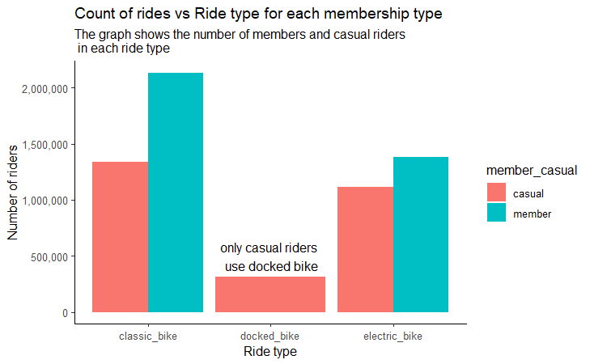

```r
ggplot(data = ride_type ,  aes(rideable_type , count , fill = member_casual)) +

geom_bar(stat = "identity",position = "dodge") +

labs(y= "Number of riders", x = "Ride type" , title = "Count of rides vs Ride type for each membership type" ,subtitle = "The graph shows the number of members and casual riders \n in each ride type") +

scale_y_continuous(labels = comma) +

theme_bw() +

theme(panel.border = element_blank(), panel.grid.major = element_blank(),
panel.grid.minor = element_blank(), axis.line = element_line(colour = "black")) +

annotate("text" , x = "docked_bike" , y = 500000 , label = "only casual riders \n use docked bike")
```

As we can see from the graph both members and casual riders use classic and electric bikes , but when it comes to docked bikes only casual riders use it.

Now we will explore how members and casual riders use bikes in different months of the year.

```r
"1-it shows that Number of members are more than casual members in all months except
for 6 , 7 , 8
"
```

```
[1] "1-it shows that Number of members are more than casual members in all months except\nfor 6 , 7 , 8\n"
```

```r
month_of_trip_df <- trip_data %>%
    group_by(month = format(started_at , format = "%m") , member_casual) %>%
    summarize(count = n())
View(month_of_trip_df)
```

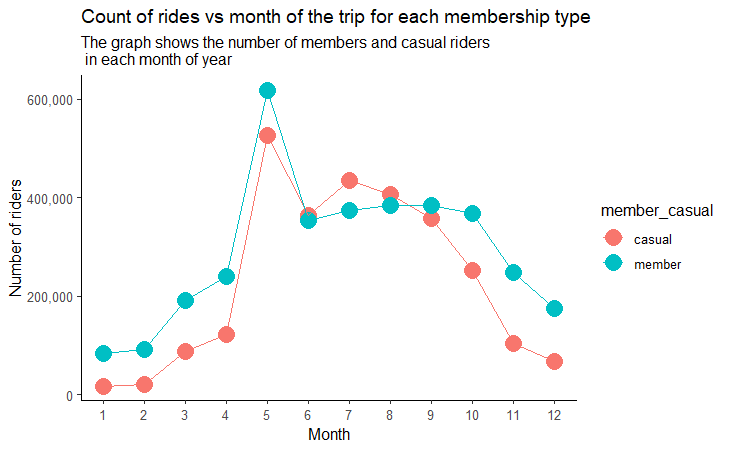

```r
month_of_trip_df$month <- as.numeric(as.character(month_of_trip_df$month))

ggplot(data = month_of_trip_df , aes(x= month , y=count , color = member_casual)) +
geom_point(size = 5 )+

geom_line()+

theme_minimal()+

scale_x_continuous(breaks = round(seq(min(month_of_trip_df$month), max(month_of_trip_df$month), by = 1),1)) +

scale_y_continuous(labels = comma) +

theme_bw() +

theme(panel.border = element_blank(), panel.grid.major = element_blank(),panel.grid.minor = element_blank(), axis.line = element_line(colour = "black")) +

labs(y= "Number of riders", x = "Month" , title = "Count of rides vs month of the trip for each membership type" ,subtitle = "The graph shows the number of members and casual riders \n in each month of year")
```

As we can see the number of rides increase significantly in months 5 -> 9

Now we will see how members and casual riders use bikes in different days of week

```r
#it shows that members get memberships to commute to work
#members are more than commuters in all week days except satrday and sunday which are the off days
day_of_trip <- wday(trip_data$started_at)

day_of_trip <- case_when(
  day_of_trip == 1 ~ "sunday",
  day_of_trip == 2 ~ "monday",
  day_of_trip == 3 ~ "tuesday",
  day_of_trip == 4 ~ "wednesday",
  day_of_trip == 5 ~ "thursday",
  day_of_trip == 6 ~ "friday",
  day_of_trip == 7 ~ "saturday"
)

day_of_trip_df <- trip_data %>%
  select( c(ride_id , member_casual) )

day_of_trip_df <- cbind(day_of_trip_df , day_of_trip)

day_of_trip_df <- day_of_trip_df %>%
    group_by(day_of_trip , member_casual) %>%
    summarize(count = n())
View(day_of_trip_df)
```

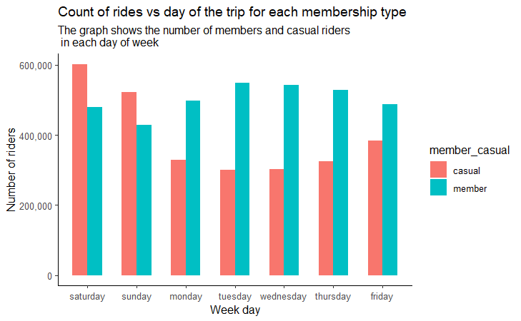

```r
day_of_trip_df$day_of_trip <- factor(day_of_trip_df$day_of_trip , levels = c('saturday' , 'sunday' ,'monday' , 'tuesday' , 'wednesday' , 'thursday' , 'friday'))
day_of_trip_df$alpha <- as.factor(ifelse(day_of_trip_df$day_of_trip == "saturday" | day_of_trip_df$day_of_trip == "sunday", 0.5 ,  1))

ggplot(data = day_of_trip_df ,  aes(day_of_trip , count , fill = member_casual ,  width = 0.6  ) ) +

guides(alpha = FALSE)+

geom_bar(stat = "identity" ,position = "dodge") +

theme_bw() +

theme(panel.border = element_blank(), panel.grid.major = element_blank(),panel.grid.minor = element_blank(), axis.line = element_line(colour = "black")) +

scale_y_continuous(labels = comma) +

labs(y= "Number of riders", x = "Week day" , title = "Count of rides vs day of the trip for each membership type" ,subtitle = "The graph shows the number of members and casual riders \n in each day of week")
```

As we can see from the graph at workdays members use more bikes than casual riders , but this is not the case at Saturday and Sunday (which might indicate that members use bikes more to commute to work or school).

Now we will see how the members and casual riders use the bikes differently in different hours

```r
#It shows that  the members use the bikes more at the start work hours (5 ~ 10 )
#and at end work hours (16~19)
hour_of_trip_df <- trip_data %>%
    group_by(hour = format(started_at , format = "%H"), member_casual) %>%
    summarize(count = n())
View(hours_of_trip_df)
```

[output not shown]

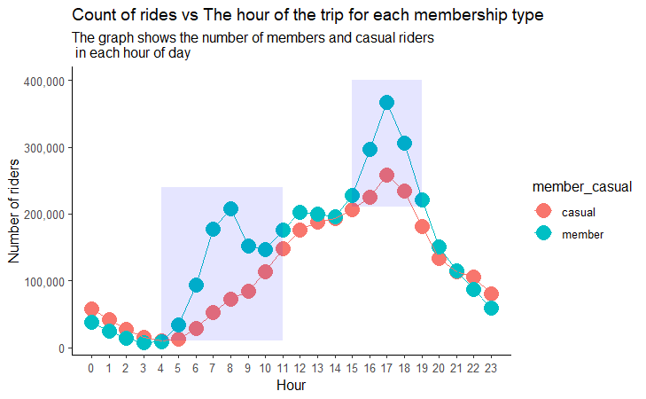

```r
hour_of_trip_df$hour <- as.numeric(as.character(hour_of_trip_df$hour))

ggplot(data = hour_of_trip_df , aes(x= hour , y=count , color = member_casual)) +
geom_point(size = 5 )+

geom_line()+

theme_minimal()+

theme_bw() +

theme(panel.border = element_blank(), panel.grid.major = element_blank(),panel.grid.minor = element_blank(), axis.line = element_line(colour = "black")) +

scale_x_continuous(breaks = round(seq(min(hour_of_trip_df$hour), max(hour_of_trip_df$hour), by = 1),1)) +

annotate("rect", xmin = 4, xmax = 11, ymin = 10000, ymax = 240000,
           alpha = .1,fill = "blue") +

annotate("rect", xmin = 15, xmax = 19, ymin = 210000, ymax = 400000,
           alpha = .1,fill = "blue") +

scale_y_continuous(labels = comma) +

labs(y= "Number of riders", x = "Hour" , title = "Count of rides vs The hour of the trip for each membership type" ,subtitle = "The graph shows the number of members and casual riders \n in each hour of day")
```

As we can see members use bikes more in these hours **(5 -> 10)** and **(15 -> 19)** which are before and after work hours , this supports that members use the bikes to commute to work .

# Important findings

- Casual riders use docked bikes and Members don`t
- Significant increase In the number of riders for both types in month 5 -> 9
- Members rides are significantly Higher than casual rides on **workdays (Monday-> Friday)**
- At weekends **(Saturday , Sunday)** we notice a significant increase in casual Rides
- Members rides are significantly Higher than casual rides before and after work hours

# Recommendations

- We can explore if the members use their bikes to go to work places or study places on work hours and workdays using longitude and latitude information
- We can explore why casual riders use docked bikes and members don`t
- Make more promotions on annual memberships during months **5 -> 9** and weekends as we can see the number of casual riders increase during this time .
- Make promotions on annual membership to casual riders who use their bikes to **commute** . And use the information we found out from the analysis to find the right timing for the promotion.